# Exam Performance

A.S., D.O.

December 5, 2018

http://roycekimmons.com/tools/generated_data/exams This dataset found on kaggle was pulled from this website. It is theoretically “exam scores for students at a public school”. However, there is an interesting disclaimer at the end that says “All data sets are fictional and should be used for educational purposes only.” That is a :thinking:

## Package Load

```r
library(dplyr)
library(ggplot2)
library(UsingR)
library(cowplot)
library(knitr)
```

## Load Data

```r
full <- read.csv("StudentsPerformance.csv", header = TRUE)
dim(full)
```

```
## [1] 1000    8
```

```r
head(full)
```

```
##   gender race.ethnicity parental.level.of.education        lunch
## 1 female        group B           bachelor's degree     standard
## 2 female        group C                some college     standard
## 3 female        group B             master's degree     standard
## 4   male        group A          associate's degree free/reduced
## 5   male        group C                some college     standard
## 6 female        group B          associate's degree     standard
##   test.preparation.course math.score reading.score writing.score
## 1                    none         72            72            74
## 2               completed         69            90            88
## 3                    none         90            95            93
## 4                    none         47            57            44
## 5                    none         76            78            75
## 6                    none         71            83            78
```

```r
str(full)
```

```
## 'data.frame':    1000 obs. of  8 variables:
##  $ gender                     : Factor w/ 2 levels "female","male": 1 1 1 2 2 1 1 2 2 1 ...
##  $ race.ethnicity             : Factor w/ 5 levels "group A","group B",..: 2 3 2 1 3 2 2 2 4 2 ...
##  $ parental.level.of.education: Factor w/ 6 levels "associate's degree",..: 2 5 4 1 5 1 5 5 3 3 ...
##  $ lunch                      : Factor w/ 2 levels "free/reduced",..: 2 2 2 1 2 2 2 1 1 1 ...
##  $ test.preparation.course    : Factor w/ 2 levels "completed","none": 2 1 2 2 2 2 1 2 1 2 ...
##  $ math.score                 : int  72 69 90 47 76 71 88 40 64 38 ...
##  $ reading.score              : int  72 90 95 57 78 83 95 43 64 60 ...
##  $ writing.score              : int  74 88 93 44 75 78 92 39 67 50 ...
```

So it doesn’t seem like this dataset is too big. It’s a smaller sample, relatively speaking. 1000 isn’t a copious amount.

We’ve got 5 indicators about people, their gender, their race (as described in a group, we don’t know which correlate to which), their parents’ level of education, their lunch situation (probably pointing to their financial situation), and whether they did a test prep course.

To analyze, we have their writing, reading, and math scores.

## Hypothesis Testing

Null Hypothesis: There is no correction between total average exams and these co-variates.

Alternative Hypothesis: At least one co-variable Correlates with total average exams.

## Select Data

```r
math_score <- full$math.score
ave_math <- mean(math_score)
reading_score <- full$reading.score
ave_reading <- mean(reading_score)
writing_score <- full$writing.score
ave_writing <- mean(writing_score)

levels(full$gender)
```

```
## [1] "female" "male"
```

```r
levels(full$race.ethnicity)
```

```
## [1] "group A" "group B" "group C" "group D" "group E"
```

```r
levels(full$parental.level.of.education)
```

```
## [1] "associate's degree" "bachelor's degree"  "high school"
## [4] "master's degree"    "some college"       "some high school"
```

```r
levels(full$lunch)
```

```
## [1] "free/reduced" "standard"
```

```r
levels(full$test.preparation.course)
```

```
## [1] "completed" "none"
```

```r
all_exams <- ((math_score+reading_score+writing_score)/3)

full2 <- mutate(full, total_average_score = all_exams)
head(full2)
```

```
##   gender race.ethnicity parental.level.of.education        lunch
## 1 female        group B           bachelor's degree     standard
## 2 female        group C                some college     standard
## 3 female        group B             master's degree     standard
## 4   male        group A          associate's degree free/reduced
## 5   male        group C                some college     standard
## 6 female        group B          associate's degree     standard
##   test.preparation.course math.score reading.score writing.score
## 1                    none         72            72            74
## 2               completed         69            90            88
## 3                    none         90            95            93
## 4                    none         47            57            44
## 5                    none         76            78            75
## 6                    none         71            83            78
##   total_average_score
## 1            72.66667
## 2            82.33333
## 3            92.66667
## 4            49.33333
## 5            76.33333
## 6            77.33333
```

## Highest Scores and Lowest scores

Here is a quick tabular glance at the attributes of the highest and lowest scores for each of the three tests as well as the average score.

```r
labels <- as.character(c("Lowest Math Score", "Highest Math Score", "Lowest Reading Score", "Highest Reading Score", "Lowest Writing Score", "Highest Writing Score", "Lowest Average Score", "Highest Average Score"))
indexes <- c(which.min(math_score), which.max(math_score), which.min(reading_score), which.max(reading_score), which.min(writing_score), which.max(writing_score), which.min(all_exams), which.max(all_exams))
actualscores <- c(min(math_score), max(math_score), min(reading_score), max(reading_score), min(writing_score), max(writing_score), min(all_exams), max(all_exams))

maxmin <- data.frame(Score = actualscores, Lunch_status = full$lunch[indexes], Parents_Education = full$parental.level.of.education[indexes], Test_Prep = full$test.preparation.course[indexes], Gender = full$gender[indexes], row.names = labels)

kable(maxmin)
```

|  | Score | Lunch_status | Parents_Education | Test_Prep | Gender |
| --- | --- | --- | --- | --- | --- |
| Lowest Math Score | 0 | free/reduced | some high school | none | female |
| Highest Math Score | 100 | free/reduced | associate’s degree | completed | male |
| Lowest Reading Score | 17 | free/reduced | some high school | none | female |
| Highest Reading Score | 100 | standard | master’s degree | none | female |
| Lowest Writing Score | 10 | free/reduced | some high school | none | female |
| Highest Writing Score | 100 | standard | master’s degree | none | female |
| Lowest Average Score | 9 | free/reduced | some high school | none | female |
| Highest Average Score | 100 | standard | bachelor’s degree | none | female |

As you can see, there are some stark differences.

## Graph Overall Distributions of 5 Attributes

Just to get an overall feel for the number of students scoring what, we’ll make some histograms. R divides the scores into bins of size 10.

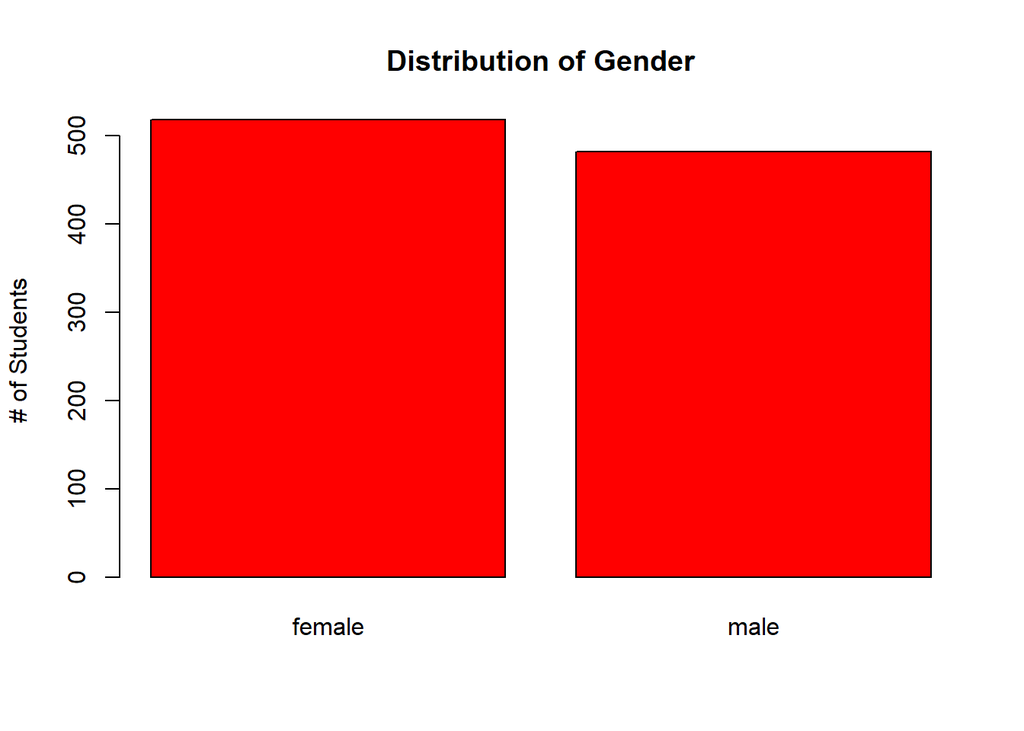

```r
table(full$gender) %>% barplot(col = "red", main = "Distribution of Gender", ylab = "# of Students")
```

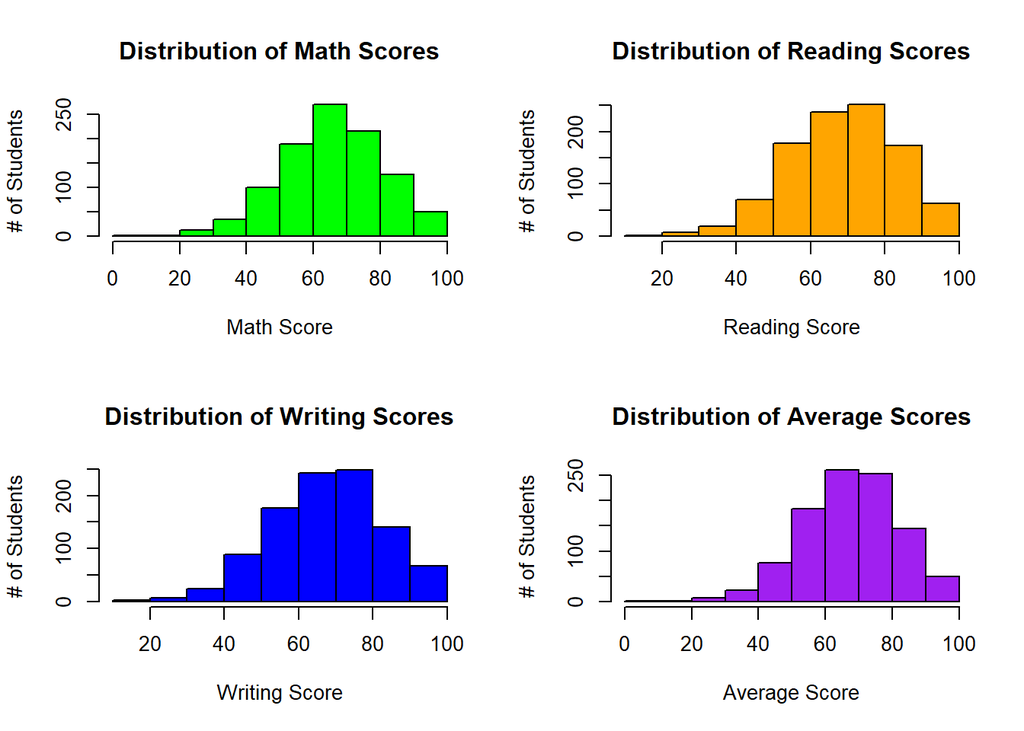

```r
par(mfrow = c(2, 2))

hist(math_score, col = "green", main = "Distribution of Math Scores", xlab = "Math Score", ylab = "# of Students")

hist(reading_score, col = "orange", main = "Distribution of Reading Scores", xlab = "Reading Score", ylab = "# of Students")

hist(writing_score, col = "blue", main = "Distribution of Writing Scores", xlab = "Writing Score", ylab = "# of Students")

hist(all_exams, col = "purple", main = "Distribution of Average Scores", xlab = "Average Score", ylab = "# of Students")
```

## Attributes vs. Average Test Scores

### Lunch Situation

The lunch situation was likely included in the data as an indication of the student’s family’s financial situation, since usually lunch programs are awarded based on financial circumstances. There are two groups here, students receiving free/reduced lunches, and students on standard (probably no) lunch plan.

### Test Preparation Course

Whether a student has taken a test preparation course may influence their score, probably for the better compared to someone who didn’t take one.

### Parents’ Education

Not only is the parents’ education indicative of perhaps how well-off the family is socioeconomically, but it also possibly influences what kind of learning environment the student grew up in at home and whether they were taught a lot or not. There is also the debateable element of whether there is any genetic influence.

```r
summary(all_exams)
```

```
##    Min. 1st Qu.  Median    Mean 3rd Qu.    Max.
##    9.00   58.33   68.33   67.77   77.67  100.00
```

```r
IQR(all_exams)
```

```
## [1] 19.33333
```

```r
sd(all_exams)
```

```
## [1] 14.25733
```

```r
full2$parental.level.of.education <- factor(full2$parental.level.of.education, levels(full2$parental.level.of.education)[c(6, 3, 5, 1, 2, 4)])
full2$test.preparation.course <- factor(full2$test.preparation.course, levels(full2$test.preparation.course)[c(2, 1)])

p1 <- ggplot(data = full2) +
  geom_boxplot(mapping = aes(x = factor(lunch), y = all_exams, fill = factor(lunch))) +
  theme(legend.title=element_blank()) +
  ggtitle("Lunch vs Avg Score") +
  xlab("Lunch Program") +
  ylab("Total Average Score")
p2 <- ggplot(data = full2) +
  geom_boxplot(mapping = aes(x = factor(test.preparation.course), y = all_exams, fill = factor(test.preparation.course))) +
  theme(legend.title=element_blank()) +
  ggtitle("Test Prep vs Avg Score") +
  xlab("Test Prep") +
  ylab("Total Average Score")
p3<- ggplot(data = full2) +
  geom_boxplot(mapping = aes(x = factor(parental.level.of.education), y = all_exams, fill = factor(parental.level.of.education))) +
  theme(legend.title=element_blank()) +
  ggtitle("Parents' Education vs Avg Score") +
  xlab("Parents' Education") +
  ylab("Total Average Score")
```

[output not shown]

Let’s also do t-tests for the two variables that have two different options.

```r
t.test(all_exams~full2$lunch)
```

```
##
##  Welch Two Sample t-test
##
## data:  all_exams by full2$lunch
## t = -9.3232, df = 674.61, p-value < 2.2e-16
## alternative hypothesis: true difference in means is not equal to 0
## 95 percent confidence interval:
##  -10.457360  -6.818936
## sample estimates:
## mean in group free/reduced     mean in group standard
##                   62.19906                   70.83721
```

```r
t.test(all_exams~full2$test.preparation.course)
```

```
##
##  Welch Two Sample t-test
##
## data:  all_exams by full2$test.preparation.course
## t = -8.5945, df = 791.84, p-value < 2.2e-16
## alternative hypothesis: true difference in means is not equal to 0
## 95 percent confidence interval:
##  -9.373305 -5.887734
## sample estimates:
##      mean in group none mean in group completed
##                65.03894                72.66946
```

## Conclusion

Therefore, we reject the null hypothesis. We know that lunch situations and test preparation courses are correlates with student exams score. We aren’t sure if the students’ parents education correlate with the exams.